# Create a distance raster from spatial points in R

Ricardo Ochoa, Eduardo Denicia

8/28/2018

This tutorial will guide you in a step-by-step process to create create a distance raster from spatial points. This tutorial considers that you are already familiar with the following concepts. If you are not, please visit the links.

- [R](https://www.r-project.org/)
- [RStudio](https://www.rstudio.com)
- [Raster](https://en.wikipedia.org/wiki/Raster_graphics)

## 1. Load required libraries

In this tutorial we will use the following libraries: [raster](https://cran.r-project.org/web/packages/raster/raster.pdf): Title Geographic Data Analysis and Modeling Version 2.6-7, November 12, 2017 [rgdal](https://cran.r-project.org/web/packages/rgdal/rgdal.pdf): Bindings for the ‘Geospatial’ Data Abstraction, Version 1.3-4, August 3, 2018 [sp](https://cran.r-project.org/web/packages/sp/sp.pdf): Classes and Methods for Spatial Data, Version 1.3-1, June 5, 2018 [leaflet](https://cran.r-project.org/web/packages/leaflet/leaflet.pdf): Create Interactive Web Maps with the JavaScript ‘Leaflet’, Version 2.0.2, August 27, 2018

Run the following lines to load the libraries.

```r
# install.packages('raster')    # Run only once
# install.packages('rgdal')     # Run only once
# install.packages('sp')        # Run only once
# install.packages('leaflet')   # Run only once
library(raster)
library(rgdal)
library(sp)
library(leaflet)
```

## 2. Prepare data

If you want to replicate this tutorial, please download the data from our GitHub repository: distance_raster. Notice that you will need the contents of the _input file. As you will notice inputs include a TIF file (raster) with the built-up are in Denpasar Metro Area and a CSV file, with the location of all [public hospitals in Denpasar](http://geoportal.denpasarkota.go.id:8080/geoserver/web/).

First of all, we will import and explore the data.

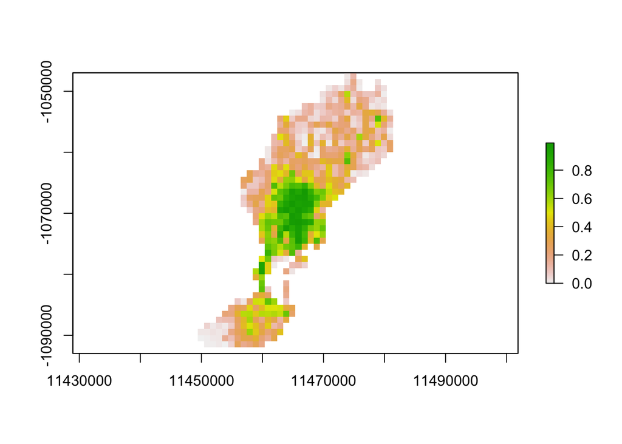

```r
built_up  <- raster("_input/denpasar_builtup.tif")
plot(built_up)
```

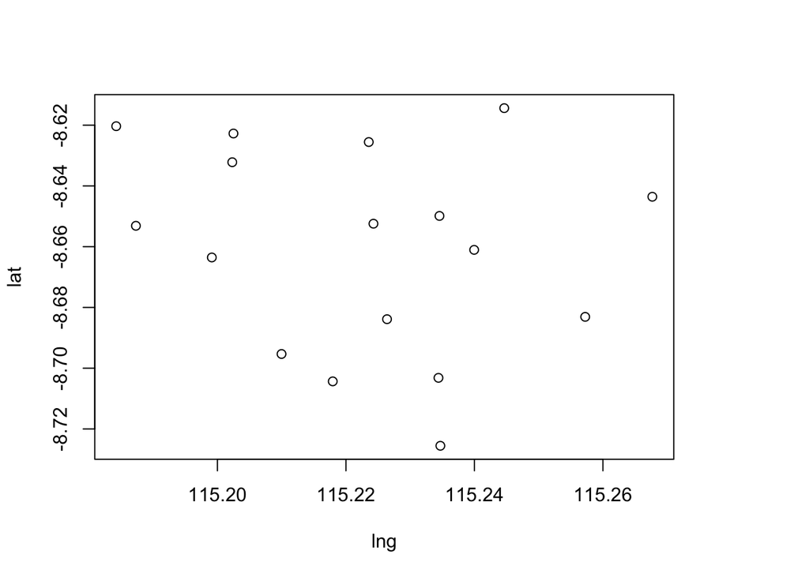

```r
hospitals <- read.csv("_input/hospitals.csv")
plot(hospitals[c("lng", "lat")])
```

Please note from both plots that **hospitals** and **built-up** have different CRS.

## 3. Estimate the distance

The distance estimation requires only a couple of lines. However, you might need to transform your data to match CRS between layers. In our example we will transform all hospital points to the built-up raster’s CRS.

```r
ghsl_crs <- '+proj=moll +lon_0=0 +x_0=0 +y_0=0 +ellps=WGS84 +datum=WGS84 +units=m +no_defs'

# Read the hospitals data
points <- SpatialPointsDataFrame(coords = hospitals[c("lng", "lat")], data = hospitals,
                                 proj4string = CRS("+proj=longlat +datum=WGS84 +ellps=WGS84 +towgs84=0,0,0"))

# Transform the CRS
points <- spTransform(x = points, CRSobj = ghsl_crs)
```

Once that we have the same CRS in both sources, we can estimate the distances with the following code. Please note that the **distanceFromPoints** function will estimate the shortest distance (in meters) to the nearest hospital.

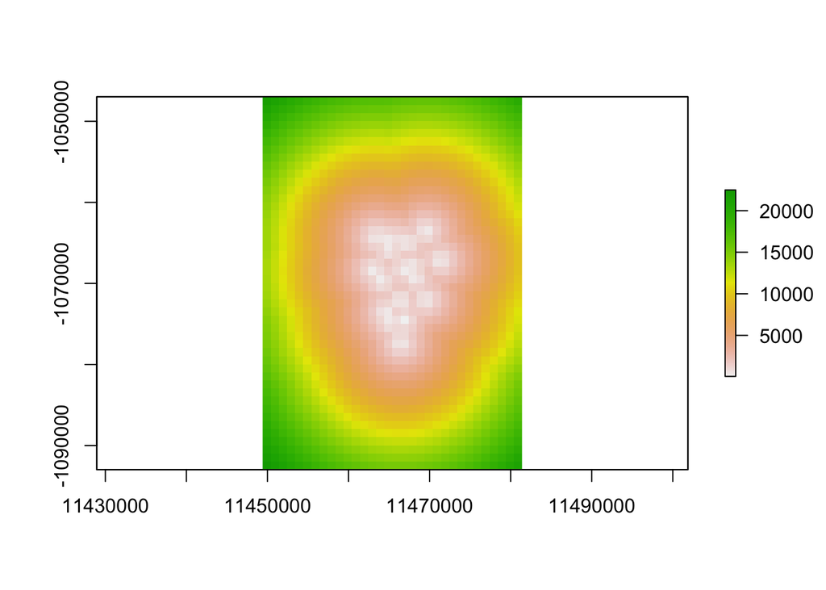

```r
# Distance from points to each raster cell
distances <- distanceFromPoints(object = built_up, xy = points)
plot(distances)
```

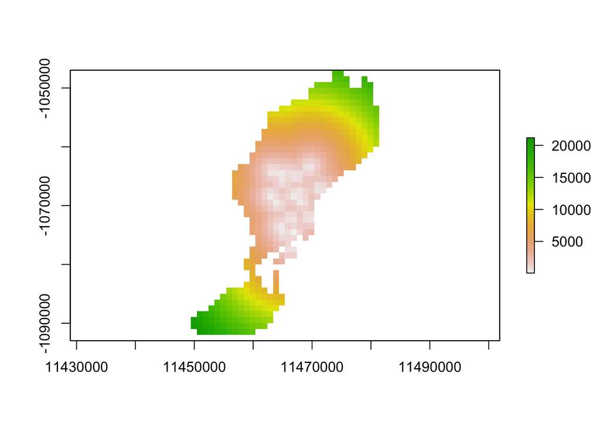

```r
# Lastly, we will "mask" the raster to keep only those cells inside CDMX
distance_raster <- mask(x = distances, mask = built_up)
plot(distance_raster)
```

## 4. Plot

Lastly, we will plot the final result using leaflet.

```r
pal <- colorNumeric(c("#556270", "#4ECDC4", "#C7F464", "#FF6B6B", "#C44D58"),
                    values(distance_raster),
                    na.color = "transparent")

leaflet() %>%
  addProviderTiles(providers$OpenStreetMap.BlackAndWhite) %>%
  addRasterImage(distance_raster, colors = pal, opacity = 0.5) %>%
  addLegend(pal = pal, values = values(distance_raster),
    title = "Distance in meters")
```

[interactive chart not shown]

## 5. Save your raster file

Save your raster file in your preferred directory.

```r
writeRaster(distance_raster, filename = "_output/distance_raster.tif", overwrite = TRUE)
```

That’s it!